# 1.智能体

## 1.什么是agent

在大模型应用开发中，智能体通常指一种以大语言模型为推理与决策核心，结合记忆、工具调用与环境交互能力，能够进行规划决策并执行复杂任务以达成目标的软件系统。  
Agent的关键能力：

- 理解用户问题
- 如何拆解任务
- 判断是否需要工具
- 需要调用哪些工具
- 如何利用好工具结果生成回答&推进任务

## 2.Agent的核心组件

实际开发中几个要素并不需要同时出现，

- 必须的：行动（Action）
- 几乎总是存在的：工具（Tool）
- 有条件存在的：规划决策（Planning）
- 最容易被省略的：记忆（Memory）

## 3.Agent创建与调用

### 1）历史上的调用

在 LangChain 0.x 时代，框架内的 Agent 系统经历了“碎片化”阶段。当时的设计理念是 “针对场景设计特定 Agent”：

- 如果你要实现思维链推理（ReAct），就用 create_react_agent ；
- 如果需要结构化输出，就用 create_structured_chat_agent ；
- 要工具调用，则用 create_tool_calling_agent 。

举例：❌ v0.x 的复杂方式

```python
# 需要多个步骤
from langchain.chat_models import init_chat_model
from langchain.agents import AgentExecutor, create_react_agent
from langchain_core.prompts import PromptTemplate
from dotenv import load_dotenv
import os

# 1. 模型初始化
load_dotenv(override=True)
load_dotenv()
model = init_chat_model(
    model="deepseek-v4-flash",
    model_provider="deepseek",
    api_key=os.getenv("DEEPSEEK_API_KEY"),
    # extra_body={
    #     "thinking":{
    #          "type": "disabled"
    #     }
    # }
)

# 2. 创建提示词模板
prompt = PromptTemplate.from_template("""
    You are a helpful assistant.

    Tools: {tools}
    Tool Names: {tool_names}

    {agent_scratchpad}
    """)

# 3. 创建 agent
agent = create_react_agent(
    llm=model,
    tools=tools,
    prompt=prompt
)

# 4. 创建 executor
executor = AgentExecutor(
    agent=agent,
    tools=tools,
    verbose=True
)
# 5. 调用
result = executor.invoke({"input": "问题"})
```

这种方式灵活，但也带来了三个明显问题：

- 1. 心智负担高——每种 Agent 都要单独记忆 API 与参数；
- 2. 可组合性差——多个 Agent 之间无法统一调度；
- 3. 生态碎片化——不同模块难以复用或协同演化。

### 2）全新的调用

LangChain 在 1.0 版本后，团队做出了彻底重构：将所有 Agent 的创建方式统一为一个入口：  
create_agent()。它取代了旧版本中的 create_react_agent 、create_json_agent 、 create_tool_calling_agent 等多种分支函数，真正让开发者用一行代码即可创建任何类型的智能体。  
同时在底层通过“中间件机制（Middleware）”和“标准模型接口（invoke / stream）”实现全局统一。这 让框架更轻、更稳，也更易于被集成到其他 Agent 平台中。

举例：✅ v1.x 的简洁方式：

```python
from langchain.chat_models import init_chat_model
from langchain.agents import create_agent

# 1. 初始化模型
model = init_chat_model("gpt-4o-mini", model_provider="openai")

# 2. 创建 agent（一步完成）
agent = create_agent(
    model=model,
    tools=[tool1, tool2],
    system_prompt="Agent 的行为指令" # 可选
)

# 3. 调用
result = agent.invoke({
    "messages": [{"role": "user", "content": "问题"}]
})
```

# 2.Agent的基本用法1：模型的传入方式

在 LangChain 1.2 中， create_agent 是构建智能体的核心方式，底层基于LangGraph 实现。

create_agent 完整参数：

```python
from langchain.agents import create_agent
agent = create_agent(
    model: str | BaseChatModel, # 必需：聊天模型
    tools: List[BaseTool], # 必需：工具列表
    *,
    system_prompt: str = "", # 系统提示词
    middleware: Seguence[AgentMiddleware[StateT_co, ContextT]] = (), # 中间件
    interrupt_before: List[str] = None, # 在某些工具前暂停（人机协作）
    interrupt_after: List[str] = None, # 在某些工具后暂停
    debug: bool = False, # 调试模式
    name: str 丨 None = None, # 设置模型名称
)
```

Agent在创建时，涉及到模型(Agent使用的模型) 、可调用工具、系统提示词等参数的设置。  
更多参数参考：https://reference.langchain.com/python/langchain/agents/factory/create_agent

Agent中模型的传入方式：  
本节我们只关注模型的传入。  
模型是 Agent 的“大脑”，负责决策和推理。根据模型传入agent方式的不同，分为两种方式。

## 2.1 传入模型字符串

Agent根据传入的模型字符串，自主创建模型对象

```python
from langchain.agents import create_agent
from dotenv import load_dotenv

load_dotenv(override=True)
agent = create_agent("deepseek-v4-flash")
print(type(agent))

from IPython.display import Image, display
display(Image(agent.get_graph().draw_mermaid_png()))
```

[output not shown]

```
<class 'langgraph.graph.state.CompiledStateGraph'>
```

## 2.2 传入模型对象

```python
from langchain.chat_models import init_chat_model
from langchain.agents import create_agent
from langchain_deepseek import ChatDeepSeek
from dotenv import load_dotenv
import os

load_dotenv(override=True)
# 以ChatDeepSeek为例
# model = ChatDeepSeek(model="deepseek-v4-flash")
# 以init_chat_model为例
model = init_chat_model(
    model="deepseek-v4-flash",
    model_provider="deepseek",
    api_key=os.getenv("DEEPSEEK_API_KEY"),
    base_url=os.getenv("DEEPSEEK_BASE_URL")
)
agent = create_agent(model)
print(type(agent))
from IPython.display import Image, display
display(Image(agent.get_graph().draw_mermaid_png()))
```

[output not shown]

```
<class 'langgraph.graph.state.CompiledStateGraph'>
```

# 3.Agent的基本用法2：如何调用Agent

agent.invoke() 是Agent 最基本的同步调用方法，它会阻塞程序执行直到返回最终结果。具体的：

- **输入**：传入的参数为字典类型，字典内通过messages字段传递消息列表。即：“ {"messages":[{"role": "...", "content": "..."}]} ”
- **输出**：通过invoke调用Agent，底层可能会经历多轮交互，返回的是完整的消息列表，被封装在字典中，是messages字段的值。

```python
response = agent.invoke({"messages": [...]})
# response 是字典类型
{
    "messages": [
        HumanMessage(...), # 用户问题
        AIMessage(...), # AI 工具调用
        ToolMessage(...), # 工具返回结果
        AIMessage(...) # 最终回答 ← 通常取这个
    ]
}

# 获取最终回答
final_answer = response['messages'][-1].content
```

举例1：

```python
from langchain.agents import create_agent
from langchain.chat_models import init_chat_model
from dotenv import load_dotenv
import os
load_dotenv(override=True)
from rich import print as rprint

# 以init_chat_model为例
model = init_chat_model(
    model="deepseek-v4-flash",
    model_provider="deepseek",
    api_key=os.getenv("DEEPSEEK_API_KEY"),
    base_url=os.getenv("DEEPSEEK_BASE_URL")
)

agent = create_agent(model=model)
response = agent.invoke({"messages": ["你好"]}) # 默认是HumanMessage
print(type(response))
rprint(response)
```

```
<class 'dict'>
```

```
{
    'messages': [
        HumanMessage(
            content='你好',
            additional_kwargs={},
            response_metadata={},
            id='12380fe9-6a03-423b-a457-d4ba0f0f1ebb'
        ),
        AIMessage(
            content='你好！很高兴见到你😊 有什么我可以帮你的吗？',
            additional_kwargs={
                'refusal': None,
                'reasoning_content': 'We need answer in Chinese. Need be careful. User says "你好" (hello). We
should respond friendly. Maybe introduce as AI assistant. Need not overdo.'
            },
            response_metadata={
                'token_usage': {
                    'completion_tokens': 49,
                    'prompt_tokens': 84,
                    'total_tokens': 133,
                    'completion_tokens_details': {
                        'accepted_prediction_tokens': None,
                        'audio_tokens': None,
                        'reasoning_tokens': 34,
                        'rejected_prediction_tokens': None
                    },
                    'prompt_tokens_details': {'audio_tokens': None, 'cached_tokens': 0},
                    'prompt_cache_hit_tokens': 0,
                    'prompt_cache_miss_tokens': 84
                },
                'model_provider': 'deepseek',
                'model_name': 'deepseek-v4-flash',
                'system_fingerprint': 'fp_a18b46594c_prod0820_fp8_kvcache_20260402',
                'id': '33820836-bb32-4e25-a613-5bf96567d5f8',
                'finish_reason': 'stop',
                'logprobs': None
            },
            id='lc_run--019ff3d1-0f59-7350-878d-7d3940a949bb-0',
            tool_calls=[],
            invalid_tool_calls=[],
            usage_metadata={
                'input_tokens': 84,
                'output_tokens': 49,
                'total_tokens': 133,
                'input_token_details': {'cache_read': 0},
                'output_token_details': {'reasoning': 34}
            }
        )
    ]
}
```

举例2：  
invoke调用的核心就是输入一系列消息（messages），每条消息通常包含 role（如 "user", "assistant","system", "tool"）和 "content"。  
我们也可以在message列表的开头加入"system"角色的消息来定义Agent的行为。

```python
from langchain.agents import create_agent
from langchain.chat_models import init_chat_model
from dotenv import load_dotenv
import os

load_dotenv(override=True)
from rich import print as rprint

# 以init_chat_model为例
model = init_chat_model(
    model="deepseek-v4-flash",
    model_provider="deepseek",
    api_key=os.getenv("DEEPSEEK_API_KEY"),
    base_url=os.getenv("DEEPSEEK_BASE_URL")
)

agent = create_agent(model)

resp = agent.invoke({
    "messages":[
        {"role":"system","content":"你是一个小学数学老师，耐心，幽默，讲解深入浅出"},
        {"role":"user","content":"100+50等于多少？"}
    ]
})

rprint(resp)
```

```
{
    'messages': [
        SystemMessage(
            content='你是一个小学数学老师，耐心，幽默，讲解深入浅出',
            additional_kwargs={},
            response_metadata={},
            id='2c53804b-4eba-4fda-b2da-b7dbef447777'
        ),
        HumanMessage(
            content='100+50等于多少？',
            additional_kwargs={},
            response_metadata={},
            id='6650bd5a-50de-4309-a3a5-e3ee9f164bad'
        ),
        AIMessage(
            content='100+50等于150呀，你看，就像你有100颗糖，再得到50颗，一共就有150颗糖，甜到心里去啦！😄',
            additional_kwargs={
                'refusal': None,
                'reasoning_content':
'我们要求解100+50。这是简单的加法。答案150。注意用户问的是小学数学，但问题简单，直接回答即可。可以幽默一点。'
            },
            response_metadata={
                'token_usage': {
                    'completion_tokens': 67,
                    'prompt_tokens': 102,
                    'total_tokens': 169,
                    'completion_tokens_details': {
                        'accepted_prediction_tokens': None,
                        'audio_tokens': None,
                        'reasoning_tokens': 32,
                        'rejected_prediction_tokens': None
                    },
                    'prompt_tokens_details': {'audio_tokens': None, 'cached_tokens': 0},
                    'prompt_cache_hit_tokens': 0,
                    'prompt_cache_miss_tokens': 102
                },
                'model_provider': 'deepseek',
                'model_name': 'deepseek-v4-flash',
                'system_fingerprint': 'fp_a18b46594c_prod0820_fp8_kvcache_20260402',
                'id': 'dc3b161d-8453-42ac-adbe-f34f929c4dbe',
                'finish_reason': 'stop',
                'logprobs': None
            },
            id='lc_run--019ff3d6-a865-76b2-81da-f74a59c813b8-0',
            tool_calls=[],
            invalid_tool_calls=[],
            usage_metadata={
                'input_tokens': 102,
                'output_tokens': 67,
                'total_tokens': 169,
                'input_token_details': {'cache_read': 0},
                'output_token_details': {'reasoning': 32}
            }
        )
    ]
}
```

# 4.Agent的基本用法3：绑定工具

只有接入了一些工具，create_agent完成Agent创建才算完整。  
Agent支持静态和动态绑定工具，后者需要用到中间件，后面会讲。在执行时：

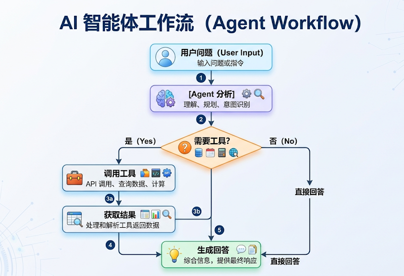

这里的工具可以是LangChain内置的，也可以是自定义的。LangChain生态中已经内置集成了非常多的实用工具，开发者可以快速调用这些工具完成更加复杂工作流的开发。  
LangChain内置工具列表：https://docs.langchain.com/oss/python/integrations/tools  
其中典型的工具如下：

| 领域 | 工具名称 | 功能说明 |
| --- | --- | --- |
| 搜索引擎与信息检索 | DuckDuckGo Search | 免费搜索引擎，返回网页标题、摘要与链接，常用于联网问答。 |
|  | Brave Search API | 提供隐私友好的网页搜索结果，可配置输出深度与过滤。 |
|  | Bing Search Tool | 微软 Bing 搜索接口，支持精确检索与多语言查询。 |
| 网页浏览与内容提取 | Playwright Browser Toolkit | 提供浏览器自动化访问、网页截图与文本抓取功能。 |
|  | Selenium Toolkit | 类似于 Playwright，但偏向传统网页 DOM 操控。 |
| 生产力工具集成 | Slack Toolkit | 允许 Agent 在 Slack 中发送、读取或总结消息。 |
|  | Jira Toolkit | 用于查询、创建或更新 Jira 项目工单。 |
|  | Google Drive / Docs Toolkit | 操作 Google 文档、表格与文件搜索。 |
| 数据库与数据操作 | SQLDatabase Toolkit | 连接 SQL 数据库，自动生成并执行 SQL 查询。 |
|  | Faiss / Chroma / Milvus VectorStore Tools | 进行向量相似度搜索，用于 RAG 检索。 |
| 代码与终端执行 | Python REPL Tool | 执行 Python 代码片段并返回结果（沙盒环境）。 |
|  | Shell Tool (Bash) | 允许执行 Shell 命令（需安全限制）。 |
|  | Requests Wrapper Tool | 发起 HTTP 请求、API 调用，用于外部数据交互。 |
| 多模态工具 | DALL-E Tool | 生成图像，可结合文本描述创作内容。 |
|  | SerpAPI Image Search | 图片搜索引擎，可返回图片 URL 与元信息。 |
|  | OpenAI Whisper Tool | 音频转录工具，将语音文件转换为文本。 |
| 知识问答与嵌入检索 | VectorStoreRetrieverTool | 基于嵌入模型检索文档片段，用于 RAG 问答。 |
|  | MultiQueryRetrieverTool | 生成多种查询变体以提升检索覆盖率。 |
| 云与AI服务 | OpenAI Functions / Azure Functions Tool | 让 Agent 调用 OpenAI 或 Azure 定义的函数。 |
|  | Anthropic ToolKit | 集成 Claude 模型工具调用能力。 |
| 文件系统与数据处理 | CSV Toolkit | 读取、过滤与分析 CSV 文件数据。 |
|  | Pandas DataFrame Agent Tool | 直接在 DataFrame 上执行查询与统计任务。 |

## 1）基本用法

Agents支持绑定一或多个工具。

### 举例1：绑定一个工具

调用查询天气工具进行天气查询：

```python
from langchain.agents import create_agent
from langchain.tools import tool
from rich import print as rprint

@tool(parse_docstring=True)
def get_weather(city: str) -> str:
    """
    天气查询工具

    Args:
        city:城市名称
    """
    return f"{city}的天气为晴朗，25摄氏度"

agent = create_agent(
    model = model,
    tools = [get_weather]
)

resp = agent.invoke({
    "messages":[
        {"role":"system","content":"你是一个天气查询助手，只回答天气相关的问题，其他问题请直接回答：我不清楚这问题答案。"},
        {"role":"user","content":"上海的天气怎么样？"},
        #{"role":"user","content":"100+50等于多少？"}
    ]
})

rprint(resp)
```

```
{
    'messages': [
        SystemMessage(
            content='你是一个天气查询助手，只回答天气相关的问题，其他问题请直接回答：我不清楚这问题答案。',
            additional_kwargs={},
            response_metadata={},
            id='a8fed6f7-ee8d-4f23-a257-46cfcde4b9ce'
        ),
        HumanMessage(
            content='上海的天气怎么样？',
            additional_kwargs={},
            response_metadata={},
            id='05b4eb55-58d2-438b-9ab9-e8c402d7148d'
        ),
        AIMessage(
            content='',
            additional_kwargs={
                'refusal': None,
                'reasoning_content': 'The user is asking about the weather in Shanghai. This is a weather-related
question, so I should use the weather tool. Let me query the weather for Shanghai.'
            },
            response_metadata={
                'token_usage': {
                    'completion_tokens': 78,
                    'prompt_tokens': 384,
                    'total_tokens': 462,
                    'completion_tokens_details': {
                        'accepted_prediction_tokens': None,
                        'audio_tokens': None,
                        'reasoning_tokens': 33,
                        'rejected_prediction_tokens': None
                    },
                    'prompt_tokens_details': {'audio_tokens': None, 'cached_tokens': 0},
                    'prompt_cache_hit_tokens': 0,
                    'prompt_cache_miss_tokens': 384
                },
                'model_provider': 'deepseek',
                'model_name': 'deepseek-v4-flash',
                'system_fingerprint': 'fp_a18b46594c_prod0820_fp8_kvcache_20260402',
                'id': '8c796141-1eae-404b-9a88-35fff8bdee5d',
```

[output cut: 50 more lines]

```
                'logprobs': None
            },
            id='lc_run--019ff3e2-a466-7283-ad1c-34c91e150a62-0',
            tool_calls=[],
            invalid_tool_calls=[],
            usage_metadata={
                'input_tokens': 481,
                'output_tokens': 11,
                'total_tokens': 492,
                'input_token_details': {'cache_read': 256},
                'output_token_details': {'reasoning': 0}
            }
        )
    ]
}
```

进一步：

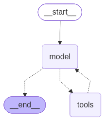

```python
from IPython.display import Image, display

display(Image(agent.get_graph().draw_mermaid_png()))
```

### 举例2：接入内置工具

绑定内置的TavilySearch搜索工具，可以借助Tavily进行网络搜索和信息爬取。  
这里我们需要先在tavily官网注册并获得API-KEY（每月有免费额度）：[https://www.tavily.com/。](https://www.tavily.com/%E3%80%82)

```python
from langchain_tavily import TavilySearch
from dotenv import load_dotenv
import os

load_dotenv(override=True)
web_search = TavilySearch(
    tavily_api_key=os.getenv("TAVILY_API_KEY"),
    max_results=2
)

#这是一个高度封装的网络搜索工具，可以直接调用：
web_search.invoke("请问2026年足球世界杯有哪些参赛队？")
```

```
{'query': '请问2026年足球世界杯有哪些参赛队？',
 'follow_up_questions': None,
 'answer': None,
 'images': [],
 'results': [{'url': 'https://baike.baidu.com/item/2026%E5%B9%B4%E5%9B%BD%E9%99%85%E8%B6%B3%E8%81%94%E4%B8%96%E7%95%8C%E6%9D%AF/62863018',
   'title': '2026年国际足联世界杯',
   'content': '| 地区 | 球队 | 出线日期 | 参赛  次数  含2026 | 最好成绩  （年份） |\n ---  --- \n| 东道主  （Host，3支球队） | 美国国家男子足球队 | 2018年6月13日 | 12 | 季军（1930） |\n| 加拿大国家男子足球队 | 2018年6月13日 | 3 | 小组赛（1986、  2022年2次） |\n| 墨西哥国家男子足球队 | 2018年6月13日 | 18 | 八强（1970、1986） |\n| 欧洲足球协会联盟  （UEFA，16支球队） | 英格兰男子足球代表队 | 2025年10月15日 | 17…
   'score': 0.8934678,
   'raw_content': None,
   'id': 'f0d4e9-00'},
  {'url': 'https://zh.wikipedia.org/wiki/2026%E5%B9%B4%E5%9C%8B%E9%9A%9B%E8%B6%B3%E5%8D%94%E4%B8%96%E7%95%8C%E7%9B%83',
   'title': '2026年國際足總世界盃',
   'content': '|  FIFA World Cup 26  Copa Mundial de la FIFA 2026  Coupe du Monde FIFA 2026 |\n|  We Are 26  Somos 26  Nous Sommes 26 |\n| 賽事資料 |\n| 主辦国家／地区 | 加拿大 墨西哥 美國 |\n| 比賽日期 | 6月11日–7月19日 |\n| 參賽隊數 | 48 隊（來自6個大洲） |\n| 球場 | 16 個（位於16個城市） |\n| 最終成績 |\n| 冠軍 | 西班牙（第 2 次奪冠） |\n| 亞軍 | 阿根廷 |\n| 季軍 | …
   'score': 0.88420963,
   'raw_content': None,
   'id': '78c9bf-01'}],
 'response_time': 1.08,
 'request_id': '8be2c33d-ee3f-4403-bb9a-0fcdfb868419'}
```

可以直接带入create_agent中作为外部工具。

```python
from langchain.chat_models import init_chat_model
from langchain.agents import create_agent
from langchain_tavily import TavilySearch
from dotenv import load_dotenv
import os
from rich import print as rprint

load_dotenv(override=True)

# 1.模型初始化
model = init_chat_model(
    model="deepseek-v4-flash",
    model_provider="deepseek",
    api_key=os.getenv("DEEPSEEK_API_KEY"),
    base_url=os.getenv("DEEPSEEK_BASE_URL")
)

# 2.工具实例化
web_search = TavilySearch(
    tavily_api_key=os.getenv("TAVILY_API_KEY"),
    max_results=2)

# 3.创建Agent
agent = create_agent(
    model = model,
    tools = [web_search],
    system_prompt="你是一名多才多艺的智能助手，可以调用工具帮助用户解决问题。"
)

# 4.运行Agent获得结果
result = agent.invoke({
    "messages":[
        {"role":"user","content":"请帮我查询2024年诺贝尔物理学奖得主是谁？"}
    ]
})

rprint(result)
# print(result['messages'][-1].content)
```

```
{
    'messages': [
        HumanMessage(
            content='请帮我查询2024年诺贝尔物理学奖得主是谁？',
            additional_kwargs={},
            response_metadata={},
            id='74cf79ca-ae96-4054-82b3-b14741a738d4'
        ),
        AIMessage(
            content='',
            additional_kwargs={
                'refusal': None,
                'reasoning_content': 'The user is asking about the 2024 Nobel Prize in Physics winners. Let me
search for this information.'
            },
            response_metadata={
                'token_usage': {
                    'completion_tokens': 76,
                    'prompt_tokens': 1918,
                    'total_tokens': 1994,
                    'completion_tokens_details': {
                        'accepted_prediction_tokens': None,
                        'audio_tokens': None,
                        'reasoning_tokens': 22,
                        'rejected_prediction_tokens': None
                    },
                    'prompt_tokens_details': {'audio_tokens': None, 'cached_tokens': 1792},
                    'prompt_cache_hit_tokens': 1792,
                    'prompt_cache_miss_tokens': 126
                },
                'model_provider': 'deepseek',
                'model_name': 'deepseek-v4-flash',
                'system_fingerprint': 'fp_a18b46594c_prod0820_fp8_kvcache_20260402',
                'id': 'fc31a863-1d52-40fc-9ac9-501da178cc18',
                'finish_reason': 'tool_calls',
                'logprobs': None
            },
            id='lc_run--019ff3ed-e65f-76f0-add1-ad68b0b4f674-0',
            tool_calls=[
                {
```

[output cut: 95 more lines]

```
                'logprobs': None
            },
            id='lc_run--019ff3ed-eec1-7802-8302-8d8216e20eac-0',
            tool_calls=[],
            invalid_tool_calls=[],
            usage_metadata={
                'input_tokens': 3117,
                'output_tokens': 324,
                'total_tokens': 3441,
                'input_token_details': {'cache_read': 1920},
                'output_token_details': {'reasoning': 0}
            }
        )
    ]
}
```

如果仔细观察本次运行过程，本次工具调用仍然是一次典型的Function calling执行流程，包括用户首次发起消息在内，总共创建了4条消息，分别是human message、ai message (涉及function call message）、tool message（涉及function response message）以及ai message（涉及final responses）。  
一次完整的Function calling 执行流程如下：

[figure not shown]

### 举例3：绑定多个工具

```python
from langchain.agents import create_agent
from langchain.tools import tool
from dotenv import load_dotenv
from rich import print as rprint

load_dotenv()

@tool(parse_docstring=True)
def get_weather(city: str):
    """
    天气查询工具

    Args:
        city: 城市名称
    """
    return f"{city}今天天气挺好"

@tool(parse_docstring=True)
def get_news():
    """
    新闻查询工具
    """
    return "近期，受全球储蓄芯片短缺等多重因素影响，多地回收商称废旧手机回收市场迎来“火热潮”，回收价格普遍上涨，旧手机成“香饽饽”。"

agent = create_agent(
    model=model,
    tools=[get_weather, get_news]
)

response = agent.invoke({
    "messages":["你好，杭州今天的天气如何？今天有哪些新闻？"]
})

rprint(response)
```

```
{
    'messages': [
        HumanMessage(
            content='你好，杭州今天的天气如何？今天有哪些新闻？',
            additional_kwargs={},
            response_metadata={},
            id='2df0024b-ebd1-4b1f-a00d-bc8bd0ed657f'
        ),
        AIMessage(
            content='',
            additional_kwargs={
                'refusal': None,
                'reasoning_content': "The user asks about weather in Hangzhou and today's news. These are
independent calls, so I can make them in the same block."
            },
            response_metadata={
                'token_usage': {
                    'completion_tokens': 88,
                    'prompt_tokens': 397,
                    'total_tokens': 485,
                    'completion_tokens_details': {
                        'accepted_prediction_tokens': None,
                        'audio_tokens': None,
                        'reasoning_tokens': 28,
                        'rejected_prediction_tokens': None
                    },
                    'prompt_tokens_details': {'audio_tokens': None, 'cached_tokens': 0},
                    'prompt_cache_hit_tokens': 0,
                    'prompt_cache_miss_tokens': 397
                },
                'model_provider': 'deepseek',
                'model_name': 'deepseek-v4-flash',
                'system_fingerprint': 'fp_a18b46594c_prod0820_fp8_kvcache_20260402',
                'id': '2086d06b-ebbb-4d0b-871b-9bed62e417ad',
                'finish_reason': 'tool_calls',
                'logprobs': None
            },
            id='lc_run--019ff3f8-18a4-7482-bd72-4ff09fd07c63-0',
            tool_calls=[
                {
```

[output cut: 54 more lines]

```
                'logprobs': None
            },
            id='lc_run--019ff3f8-1cb8-7c80-bce9-bedbdf5808f5-0',
            tool_calls=[],
            invalid_tool_calls=[],
            usage_metadata={
                'input_tokens': 549,
                'output_tokens': 79,
                'total_tokens': 628,
                'input_token_details': {'cache_read': 384},
                'output_token_details': {'reasoning': 0}
            }
        )
    ]
}
```

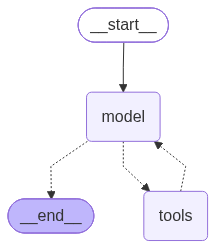

```python
from IPython.display import Image, display

display(Image(agent.get_graph().draw_mermaid_png()))
```

注意：只给 Agent 需要的工具，工具太多会混淆。一般2-5 个工具最佳

## 2）工具调用流程分析

LangChain 的 Agent 会将模型与工具结合起来，在实现上由一个基于 LangGraph 的图结构来编排执行流程，如下所示。

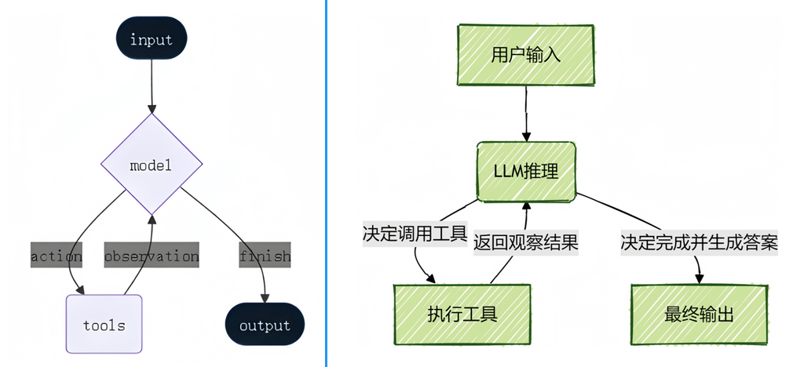

这与前文得到的 Agent 图结构是一致的，本质上就是经典的 ReAct 结构：一个具备“ 思考-行动-观察”不断循环的自主工作者。

用户问题 → AI 思考 → 调用工具 → 观察结果 → 继续思考 → ... → 最终答案

当用户提出一个复杂需求时，Agent会像人类一样，先理解任务、规划步骤、使用合适的工具（如搜索网络、查询数据库、执行计算）获取信息，Agent 会在一个循环中反复调用模型和工具，直到某次模型输出中不再包含工具调用则结束，最后综合所有信息给出最终答案。

完整流程：

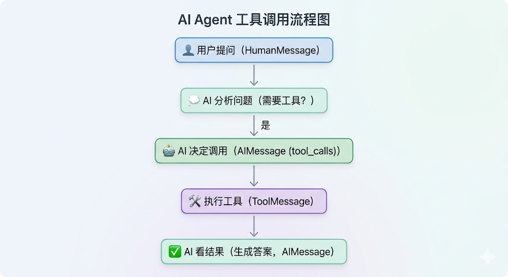

### 举例：用户问题：“找出当前最流行的无线耳机并检查库存”的任务。

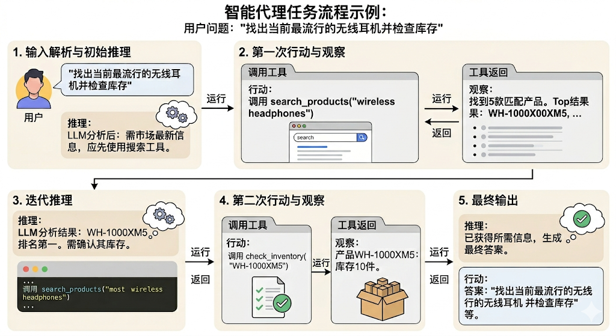

**1、输入解析与初始推理**

- 输入：用户查询：“找出当前最流行的无线耳机并检查库存”。
- 推理：LLM分析任务后认为：“要找出‘最流行’的产品，需要最新的市场信息，我应该先使用搜索工具。”

**2、第一次行动(action)与观察(observation)**

- 行动：Agent调用search_products工具，参数为“wireless headphones”。
- 观察：工具返回结果：“找到5款匹配产品。Top结果：WH-1000XM5, ...”

**3、迭代推理**

- 推理：LLM根据搜索结果分析：“WH-1000XM5是排名第一的型号。现在需要确认其库存状态才能回答用户问题。”

**4、第二次行动(action)与观察(observation)**

- 行动：Agent调用check_inventory工具，参数为“WH-1000XM5”。
- 观察：工具返回：“产品WH-1000XM5：库存10件。”

**5、最终输出**

- 推理：LLM综合所有信息后认为：“已获得所需信息，可以生成最终答案。”
- 行动：模型生成最终答案，不再调用工具。

## 3）重试机制

Agent可以在工具调用结果不满足要求时，自主重试。

```python
from langchain.agents import create_agent
from langchain.tools import tool
from langchain.messages import SystemMessage, HumanMessage
from dotenv import load_dotenv
from rich import print as rprint

load_dotenv(override=True)
flag = 0
@tool
def get_weather(city: str):
    """
    天气查询工具

    Args:
        city: 城市名称
    """
    global flag
    flag += 1

    if flag < 3:
        # raise Exception("暂时无法访问")
        return "TEMP_UNAVAILABLE: 天气服务暂时不可用，请稍后重试"

    return f"{city}今天天气挺好"

messages = [
    SystemMessage("""
    你是一个天气助手。
    当工具返回以 'TEMP_UNAVAILABLE:' 开头的结果时，
    说明是临时故障，不要立即放弃；
    你应再次调用同一个工具，最多重试 3 次。
    如果 3 次后仍失败，再向用户说明服务暂时不可用。
    """),
    HumanMessage("你好，杭州今天的天气如何？")
]

agent = create_agent(model, tools=[get_weather])
response = agent.invoke({"messages": messages})

# rprint(response)

for msg in response["messages"]:
    msg.pretty_print()
```

```
================================ System Message ================================


    你是一个天气助手。
    当工具返回以 'TEMP_UNAVAILABLE:' 开头的结果时，
    说明是临时故障，不要立即放弃；
    你应再次调用同一个工具，最多重试 3 次。
    如果 3 次后仍失败，再向用户说明服务暂时不可用。

================================ Human Message =================================

你好，杭州今天的天气如何？
================================== Ai Message ==================================
Tool Calls:
  get_weather (call_00_5iWwAsfNtVxEM0BWULD09364)
 Call ID: call_00_5iWwAsfNtVxEM0BWULD09364
  Args:
    city: 杭州
================================= Tool Message =================================
Name: get_weather

TEMP_UNAVAILABLE: 天气服务暂时不可用，请稍后重试
================================== Ai Message ==================================

天气服务返回了临时故障提示，我马上再试一次。
Tool Calls:
  get_weather (call_00_iZr1S2FLesraBCGEMuua1819)
 Call ID: call_00_iZr1S2FLesraBCGEMuua1819
  Args:
    city: 杭州
================================= Tool Message =================================
Name: get_weather

TEMP_UNAVAILABLE: 天气服务暂时不可用，请稍后重试
================================== Ai Message ==================================

仍是临时故障，我继续重试。
Tool Calls:
  get_weather (call_00_ET_QdNBPf5QHAD7NkjWFZ6p1107)
 Call ID: call_00_ET_QdNBPf5QHAD7NkjWFZ6p1107
  Args:
    city: 杭州
================================= Tool Message =================================
Name: get_weather

杭州今天天气挺好
================================== Ai Message ==================================

杭州今天天气挺好的！阳光和天气状况都不错，适合外出活动。祝你有愉快的一天！☀️
```

模型三次调用get_weather ，最终获得了满意的结果。

## 4）常见问题

### 问题1：Agent 如何选择工具？

依据：工具的 docstring

```python
@tool
def get_weather(city: str) -> str:
    """获取指定城市的天气信息""" # ← AI Agent读这个！
    ...

@tool
def calculator(operation: str, a: float, b: float) -> str:
    """执行基本的数学计算""" # ← AI Agent也读这个！
    ...
```

AI 会根据：

1. 问题内容
2. 每个工具的描述
3. 自动选择最匹配的工具

### 问题2：Agent 为什么没有调用工具？

原因：

- 工具的 docstring 不清晰
- 问题表述不明确
- 模型认为不需要工具

解决：

```python
# ❌ 不好
@tool
def tool1(x: str) -> str:
    """做一些事情""" # 太模糊

# ✅ 好
@tool
def get_weather(city: str) -> str:
    """
    获取指定城市的实时天气信息

    Args:
        city: 城市名称，如"北京"、"上海"
    """
```

### 问题3：Agent 选错工具？

原因：

- 多个工具的功能描述相似
- 工具太多导致混淆

解决：

- 只给必要的工具
- 工具描述要有明确区分
- 在 system_prompt 中说明工具使用场景

```python
# ✅ 好：只给需要的工具
agent = create_agent(
    model=model,
    tools=[get_weather, calculator] # 2-5 个工具最佳
)

# ❌ 不好：工具太多
agent = create_agent(
    model=model,
    tools=[tool1, tool2, ..., tool20] # 会混淆
)
```

### 问题4：如何知道 Agent 何时完成？

当 AIMessage 不包含 tool_calls 时：

```python
for msg in response['messages']:
    if isinstance(msg, AIMessage):
        if hasattr(msg, 'tool_calls') and msg.tool_calls:
            print("还在调用工具...")
        else:
            print("完成！最终答案：", msg.content)
```

### 问题5：Agent 可以调用多少次工具？

默认没有限制，直到得到最终答案。但可能会：

- 超时
- 达到 token 限制
- 模型决定停止

### 问题6：如何限制工具调用次数？

LangChain 1.0 的 create_agent 默认使用 LangGraph，可以通过配置限制：

```python
# 注意：这是高级用法，后续会详细学习
config = {
    "recursion_limit": 5 # 最多 5 步
}

response = agent.invoke(input, config=config)
```

# 5.Agent的高级用法1：设置Agent名称

创建Agent时，LangChain允许用户指定其名称

## 5.1 用法

```python
from langchain.agents import create_agent
from langchain.chat_models import init_chat_model
from dotenv import load_dotenv
import os
from rich import print as rprint

# 从.env文件中加载环境变量
load_dotenv(override=True)

model = init_chat_model(
    model="deepseek-v4-flash",
    model_provider="deepseek",
    api_key=os.getenv("DEEPSEEK_API_KEY"),
    base_url=os.getenv("DEEPSEEK_BASE_URL")
)

agent = create_agent(
    model=model,
    name = "chat_assistant"
)
response = agent.invoke({"messages": ["你好"]})

# rprint(response)
for msg in response["messages"]:
    msg.pretty_print()
```

```
================================ Human Message =================================

你好
================================== Ai Message ==================================
Name: chat_assistant

你好！有什么可以帮你的吗？
```

**输出的AI Message带有Name信息。**

## 5.2 经典使用场景

name 在 Multi-Agent 场景中最常被提及，用于区分不同的 Agent。但它的作用并不局限于多 Agent 编排。在实际工程中，出现如下场景，通常都建议为 Agent 设置一个清晰且稳定的 name 。

### 1. 流式输出归因

在启用流式输出时，name 可用于标识当前输出内容来自哪个 Agent 。  
这在多 Agent 协作、Agent 嵌套调用，或前端需要实时展示不同执行主体输出时尤其有用，便于准确区分 token 或事件的来源。

### 2. 消息身份标记

设置 name 后，Agent 产生的 AIMessage 会携带对应的name信息。 这使得系统在保存会话记录、回放执行过程、构建审计日志或前端展示消息角色时，能够明确识别消息的生成者。

### 3. 调试与trace可读性

在调试、日志分析和链路追踪过程中，name 可以作为 Agent 的稳定标识，帮助开发者快速判断当前执行的是哪个 Agent 。  
当系统中存在多个能力相近的 Agent，或一个 Agent 被嵌套在更复杂的工作流中时，名称能够显著提升trace 的可读性和问题定位效率。

### 4. 组件化封装

在工程实践中，Agent 常被封装为可复用的能力模块，例如检索助手、SQL 助手、报告生成助手等。  
为 Agent 设置 name ，有助于在模块注册、运行监控、日志归档和能力复用时保持一致的身份标识。  
如果后续需要将该 Agent 进一步作为子图节点、工具能力或子模块接入更复杂系统，也能降低维护和迁移成本。

### 5. 前端展示与运行态可观测性

在带有可视化界面的应用中，name 还可以直接作为运行时展示标识使用。  
例如，在执行面板中显示“当前活跃 Agent”“本轮输出来源”或“调用链路中的执行节点”时，name 能帮助开发者和用户更直观地理解系统当前的执行状态。

### 6. 作为稳定的运行时身份标识

从更通用的角度看，name 可以理解为 Agent 在系统中的“ 运行时身份 ID ”。  
相比临时性的展示名称，一个稳定、规范的 name 更适合用于日志检索、监控统计、链路分析和跨模块协作，因此在生产环境中通常建议显式设置，而不是依赖默认行为。

# 6.Agent的高级用法2：系统提示词

使用 create_agent 创建 Agent 时，需传入模型和工具、可选地传入系统提示词。**提示词为Agent提供了任务背景、行为准则和操作指南。**  
系统指令，即SystemMessage，通过 system_prompt 设置，定义 Agent 行为。这个参数可以是str或者SystemMessage类型。  
使用建议：

- 明确说明 Agent 的角色
- 定义输出格式
- 说明何时使用工具  
  比如：

```python
agent = create_agent(
    model=model,
    tools=[get_weather],
    system_prompt="""你是天气助手。
    工作流程：
    1. 理解用户的城市查询
    2. 使用 get_weather 工具获取数据
    3. 简洁清晰地回答

    输出格式：
    - 天气状况
    - 温度
    - 注意事项（如有）
    """
)
```

提示词设置有两种方式： 静态设置和动态设置。动态设置需要借助中间件，后续讲解。  
举例1：

```python
from langchain.chat_models import init_chat_model
from langchain.agents import create_agent
from langchain_tavily import TavilySearch
from dotenv import load_dotenv
import os
from rich import print as rprint

load_dotenv(override=True)

# 1.模型初始化
model = init_chat_model(
    model="deepseek-v4-flash",
    model_provider="deepseek",
    api_key=os.getenv("DEEPSEEK_API_KEY"),
    base_url=os.getenv("DEEPSEEK_BASE_URL")
)

# 2.工具实例化
web_search = TavilySearch(
    tavily_api_key=os.getenv("TAVILY_API_KEY"),
    max_results=2)

# 3.创建Agent
agent = create_agent(
    model = model,
    tools = [web_search],
    system_prompt="你是一名多才多艺的智能助手，可以调用工具帮助用户解决问题。"
)

# 4.运行Agent获得结果
result = agent.invoke({
    "messages":[
        {"role":"user","content":"请帮我查询2024年诺贝尔物理学奖得主是谁？"}
    ]
})

# rprint(result)
print(result['messages'][-1].content)
```

```
根据查询结果，**2024年诺贝尔物理学奖**的获奖者是：

## 🏆 获奖者

1. **约翰·J·霍普菲尔德**（John J. Hopfield，美国普林斯顿大学）
2. **杰弗里·E·辛顿**（Geoffrey E. Hinton，加拿大多伦多大学）

## 🎯 获奖理由

他们因**"通过人工神经网络实现机器学习的基础性发现与发明"**而获奖。

## 📝 贡献简介

- **霍普菲尔德**：发明了以其名字命名的"霍普菲尔德网络"（Hopfield Network），这是一种能够存储和重建信息的联想记忆模型，其物理思想深受自旋玻璃（spin glass）等统计物理模型的启发。
- **辛顿**：被誉为"人工智能教父"，他基于霍普菲尔德网络发展了**玻尔兹曼机**（Boltzmann machine），为现代深度学习的发展奠定了理论基础。

值得一提的是，这两位科学家的获奖也引发了广泛讨论——因为这是物理学奖历史上首次授予与人工智能和机器学习直接相关的研究成果，标志着物理学方法（如统计力学）与计算机科学的深度融合。

---

需要我进一步介绍他们具体的科学贡献，或者查询其他年份的诺贝尔奖信息吗？
```

举例2：

```python
from langchain.agents import create_agent
from langchain_core.messages import SystemMessage
from langchain_core.tools import tool
from rich import print as rprint

# 工具：实现两数相加
@tool
def add_numbers(a: int, b: int) -> str:
    """计算并返回两个数的和。"""
    return f"和为：{a + b}"

# 创建客服助手Agent
agent = create_agent(
    model=model,
    tools=[add_numbers], # 工具列表
    # system_prompt="你是一个数学助手，解决日常的算术问题"
    system_prompt=SystemMessage(content="你是一个数学助手，解决日常的算术问题")
)
response = agent.invoke(
    {"messages": [
    {"role": "user", "content": "10加上20再加上30是多少？"}
    ]},
)

rprint(response)
# print(response["messages"][-1].content)
```

```
{
    'messages': [
        HumanMessage(
            content='10加上20再加上30是多少？',
            additional_kwargs={},
            response_metadata={},
            id='72a032de-87a8-47e2-a580-49506b7798bf'
        ),
        AIMessage(
            content='',
            additional_kwargs={
                'refusal': None,
                'reasoning_content': 'The user asks: 10 + 20 + 30 = ?\n\nI can use the add_numbers tool. But it
only takes two numbers at a time. I can add 10 and 20 first, then add 30 to the result. These are dependent, so I
must call sequentially.\n\nLet me first add 10 + 20.'
            },
            response_metadata={
                'token_usage': {
                    'completion_tokens': 130,
                    'prompt_tokens': 382,
                    'total_tokens': 512,
                    'completion_tokens_details': {
                        'accepted_prediction_tokens': None,
                        'audio_tokens': None,
                        'reasoning_tokens': 70,
                        'rejected_prediction_tokens': None
                    },
                    'prompt_tokens_details': {'audio_tokens': None, 'cached_tokens': 0},
                    'prompt_cache_hit_tokens': 0,
                    'prompt_cache_miss_tokens': 382
                },
                'model_provider': 'deepseek',
                'model_name': 'deepseek-v4-flash',
                'system_fingerprint': 'fp_a18b46594c_prod0820_fp8_kvcache_20260402',
                'id': 'd2584c67-db97-4b9e-9187-d308de0398b3',
                'finish_reason': 'tool_calls',
                'logprobs': None
            },
            id='lc_run--019ff45b-649c-7920-8cab-c75b87050009-0',
            tool_calls=[
```

[output cut: 94 more lines]

```
                'logprobs': None
            },
            id='lc_run--019ff45b-6ead-7ac2-9b49-b6b1ba24c7cf-0',
            tool_calls=[],
            invalid_tool_calls=[],
            usage_metadata={
                'input_tokens': 612,
                'output_tokens': 13,
                'total_tokens': 625,
                'input_token_details': {'cache_read': 512},
                'output_token_details': {'reasoning': 0}
            }
        )
    ]
}
```

举例3：

```python
from langchain.agents import create_agent
from langchain.tools import tool
from langchain.messages import SystemMessage, HumanMessage

flag = 0

@tool
def get_weather(city: str):
    """
    天气查询工具

    Args:
        city: 城市名称
    """
    global flag
    flag += 1

    if flag < 3:
        # raise Exception("暂时无法访问")
        return "TEMP_UNAVAILABLE: 天气服务暂时不可用，请稍后重试"
    return f"{city}今天天气挺好"

messages = [
    HumanMessage("你好，杭州今天的天气如何？")
]
agent = create_agent(
    model=model,
    tools=[get_weather],
    system_prompt=SystemMessage(
        "你是一个天气助手。"
        "当工具返回以 'TEMP_UNAVAILABLE:' 开头的结果时，"
        "说明是临时故障，不要立即放弃；"
        "你应再次调用同一个工具，最多重试 3 次。"
        "如果 3 次后仍失败，再向用户说明服务暂时不可用。"
    )
)

response = agent.invoke({"messages": messages})
# print(response)
for msg in response["messages"]:
    msg.pretty_print()
```

```
================================ Human Message =================================

你好，杭州今天的天气如何？
================================== Ai Message ==================================
Tool Calls:
  get_weather (call_00_zlrQR26x8jLm1CBxhXEL2194)
 Call ID: call_00_zlrQR26x8jLm1CBxhXEL2194
  Args:
    city: 杭州
================================= Tool Message =================================
Name: get_weather

TEMP_UNAVAILABLE: 天气服务暂时不可用，请稍后重试
================================== Ai Message ==================================
Tool Calls:
  get_weather (call_00_MvUiGGZXOdHSUrZgpbRx3444)
 Call ID: call_00_MvUiGGZXOdHSUrZgpbRx3444
  Args:
    city: 杭州
================================= Tool Message =================================
Name: get_weather

TEMP_UNAVAILABLE: 天气服务暂时不可用，请稍后重试
================================== Ai Message ==================================
Tool Calls:
  get_weather (call_00_QKD8ALxPTbyiRmGvRzFc0840)
 Call ID: call_00_QKD8ALxPTbyiRmGvRzFc0840
  Args:
    city: 杭州
================================= Tool Message =================================
Name: get_weather

杭州今天天气挺好
================================== Ai Message ==================================

杭州今天的天气挺好！☀️ 适合出门走走～
```

# 7.Agent的高级用法3：结构化输出

结构化输出是Agent的核心功能之一，它允许Agent以特定、可预测的格式返回数据，而不是传统的自然语言响应。通过结构化输出，开发者可以直接获得Pydantic模型、JSON对象或数据类等结构化数据，这些数据能够被应用程序直接使用，无需复杂的解析过程。

## 7.1 模型 vs Agent的结构化输出对比

第06章已经介绍过结构化输出，当时的重点是与模型对象的绑定，这里与Agent的结构化输出做对比：

| 维度 | 模型的结构化输出 | Agent 结构化输出 |
| --- | --- | --- |
| 操作对象 | 作用于**大模型对象** | 作用于 **Agent** |
| 解析时机 | 每次模型调用生成 `AIMessage` 时，进行解析 | 仅在 Agent 决定「任务结束」并输出最终答案时解析 |
| 数据流转 | 模型 → 结构化对象 | 模型 → 工具 → 反思 → … → 结构化对象 |
| 绑定方式 | 使用 `with_structured_output` | 使用 `response_format` 参数 |
| 适用场景 | **单次、确定性**的任务（如提取字段、翻译、分类） | **多步、复杂推理**的任务（如查文档后汇总报表） |

## 7.2 结构化输出的4种策略

LangChain的create_agent()函数自动处理结构化输出的全过程。用户只需通过“response_format”参数设置期望的输出模式（Schema）。  
当模型生成结构化数据时，系统会自动捕获、验证并将结果存储在Agent状态的structured_response键中。

```python
def create_agent(
    ...
    response_format: Union[
        ToolStrategy[StructuredResponseT],
        ProviderStrategy[StructuredResponseT],
        type[StructuredResponseT],
        None,
    ]
```

create_agent函数中的response_format参数支持四种不同的策略设置方式：

### ① ProviderStrategy

使用模型提供商的原生结构化输出功能实现结构化输出。

- 这里所说的“原生结构化输出”指的是大语言模型（LLM）提供商通过其API直接提供的、在模型响应阶段就强制保证输出格式符合预定规范的能力，这种能力能够在模型生成内容的源头确保结构化准确性。
- 适用于支持原生结构化输出的模型，比如**OpenAI、Anthropic Claude或xAI Grok**等。

注意“

1. **`deepseek-v4-flash` 不支持 OpenAI 新标准 `json_schema` 模式** `init_chat_model` 默认 `with_structured_output(method="json_schema")`，会传递 `response_format: {"type":"json_schema", ...}`，DeepSeek API 直接拒绝。
2. 同时 `deepseek-v4-flash` 开启思考模式（reasoner）时，**`function_calling` + `tool_choice="required"` 也会 400 报错**。
3. DeepSeek 仅支持基础模式：`response_format={"type":"json_object"}`（只保证合法 JSON，**不强制校验 Schema**）。

举例：

```python
from pydantic import BaseModel, Field
from langchain.agents import create_agent
from langchain.agents.structured_output import ProviderStrategy
from langchain.messages import HumanMessage
from rich import print as rprint
from langchain.chat_models import init_chat_model
from dotenv import load_dotenv
import os

load_dotenv(override=True)

# 1.模型初始化
model = init_chat_model(
    model="deepseek-v4-flash",
    model_provider="deepseek",
    api_key=os.getenv("DEEPSEEK_API_KEY"),
    base_url=os.getenv("DEEPSEEK_BASE_URL")
)

# 2.Pydantic结构化方式定义
class ContactInfo(BaseModel):
    """用户的联系方式"""
    name: str = Field(description="用户姓名")
    email: str = Field(description="用户邮箱地址")
    phone: str = Field(description="用户的手机号")

# 3.agent初始化
agent = create_agent(
    model=model,
    response_format=ProviderStrategy(ContactInfo)
)

# 4.调用
response = agent.invoke({
    "messages": [
        HumanMessage("从这段话中抽取结构化信息：小明的邮箱地址为：shkstart@atguigu.com，手机号：12345678912")
        ]
    }
)
# rprint(response)

for msg in response["messages"]:
    msg.pretty_print()
```

上面的会报错，换成gpt模型不会报错

### ② ToolStrategy

对于不支持原生结构化输出的模型，LangChain采用“ToolStrategy”工具调用的方式实现结构化输出。  
此策略兼容绝大多数支持工具调用的现代模型，其核心原理是动态创建一个" 虚拟工具"，该工具的输入参数对应着期望的数据结构。  
当模型需要生成最终答案时，系统会引导模型"调用"这个虚拟工具，从而间接产生符合要求的结构化数据。

```python
from pydantic import BaseModel
from langchain.agents import create_agent
from langchain.agents.structured_output import ToolStrategy
from langchain.chat_models import init_chat_model
from dotenv import load_dotenv
import os

load_dotenv(override=True)

# 1.模型初始化
model = init_chat_model(
    model="deepseek-v4-flash",
    model_provider="deepseek",
    api_key=os.getenv("DEEPSEEK_API_KEY"),
    base_url=os.getenv("DEEPSEEK_BASE_URL"),
    extra_body={
        "thinking":{
            "type":"disabled"
        }
    }
)

# 2.Pydantic结构化方式定义
class ContactInfo(BaseModel):
    name: str = Field(description="姓名")
    email: str = Field(description="邮箱")
    phone: str = Field(description="电话")

# 3.工具的定义（根据需要定义）
@tool
def search_tool(query: str) -> str:
    """这是一个搜索引擎。当大模型发现给定的上下文里缺少必要的联系人信息，
    需要去互联网上查询时，才会调用这个工具。
    """
    return f"搜索结果: 未找到关于 '{query}' 的更多额外信息。"

# 3.agent初始化
agent = create_agent(
    model=model,
    tools=[search_tool],
    response_format=ToolStrategy(ContactInfo)
)

result = agent.invoke({
    "messages": [{"role": "user", "content": "联系人信息: John Doe,john@atguigu.com, (010) 56253825"}]
})

# print(result)
print(result["structured_response"])
```

```
name='John Doe' email='john@atguigu.com' phone='(010) 56253825'
```

### ③ type / AutoStrategy

官方没有在参数列表或官方文档列出这种策略，但阅读源码可以看到。

```python
ResponseFormat = ToolStrategy[SchemaT] | ProviderStrategy[SchemaT] |
AutoStrategy[SchemaT]
"""Union type for all supported response format strategies."""
```

当我们直接传入一个定义类型时，LangChain会自动包装为AutoStrategy，触发自动选择策略：如果模型支持原生结构化输出（如OpenAI、Anthropic Claude或xAI Grok），则优先使用ProviderStrategy；否则使用ToolStrategy。

举例1：

```python
from langchain.agents.structured_output import AutoStrategy
from pydantic import BaseModel, Field
from langchain.agents import create_agent


class ContactInfo(BaseModel):
    """联系人信息"""
    name: str = Field(description="姓名")
    email: str = Field(description="邮箱")
    phone: str = Field(description="电话")

agent = create_agent(
    model=model,
    response_format=AutoStrategy(ContactInfo)
)

result = agent.invoke({
    "messages": [{"role": "user", "content": "联系人信息: John Doe,john@atguigu.com, (010) 56253825"}]
})

# print(result)
print(result["structured_response"])
```

```
name='John Doe' email='john@atguigu.com' phone='(010) 56253825'
```

特别注意：在LangChain 1.0及以上版本中，直接传递模式（如response_format=ContactInfo）不再支持，必须显式使用ToolStrategy或ProviderStrategy。（经过测试，目前LangChain 1.2版本还可使用）。

举例2：

```python
from pydantic import BaseModel, Field
from langchain.agents import create_agent

class ContactInfo(BaseModel):
    """联系人信息"""
    name: str = Field(description="姓名")
    email: str = Field(description="邮箱")
    phone: str = Field(description="电话")

agent = create_agent(
    model=model,
    response_format=ContactInfo # Auto-selects ProviderStrategy
)

result = agent.invoke({
    "messages": [{"role": "user", "content": "联系人信息: John Doe,john@atguigu.com, (010) 56253825"}]
})

# print(result)
print(result["structured_response"])
```

```
name='John Doe' email='john@atguigu.com' phone='(010) 56253825'
```

### ④ None

默认配置，表示不以结构化输出，以自然语言响应用户问题。

```python
from pydantic import BaseModel, Field
from langchain.agents import create_agent



agent = create_agent(
    model=model,
)

result = agent.invoke({
    "messages": [{"role": "user", "content": "联系人信息: John Doe,john@atguigu.com, (010) 56253825"}]
})

# print(result)
print(result)
```

````
{'messages': [HumanMessage(content='联系人信息: John Doe,john@atguigu.com, (010) 56253825', additional_kwargs={}, response_metadata={}, id='b2d2e689-bf85-43fd-8afd-3beaa22afea8'), AIMessage(content='这是一个典型的联系人信息条目。根据您的需求，我可以为您整理成以下清晰、规范的格式，并附上使用建议。\n\n### 1. 标准格式（适用于名片、通讯录）\n\n```\n姓名：John Doe\n邮箱：john@a…
````

**总结：** 在实际大模型Agent开发场景中，如果使用到了结构化输出，推荐使用“ToolStrategy”策略，所以后续重点介绍这种策略方式结构化输出。

## 7.3 ToolStrategy使用详解

ToolStrategy通过工具调用（Tool Calling/Function Calling）实现结构化输出，所以LangChain会在消息列表末尾追加一条ToolMessage ，让整个链路完整。但实际上没有实际的工具执行，这是一条伪消息。

ToolStrategy适用于任何支持工具调用的现代模型。

ToolStrategy的配置包含三个主要参数：

```python
class ToolStrategy(Generic[SchemaT]):
    schema: type[SchemaT]
    tool_message_content: str | None
    handle_errors: Union[bool, str, type[Exception], tuple[type[Exception],
    ...], Callable[[Exception], str]]
```

- schema（必需参数）：与提供商策略的schema参数功能一致，支持Pydantic模型、TypedDict 、JSON Schema 、数据类(@dataclass) ，同时还支持联合类型Union[类型1, 类型2] （允许模型根据输入内容选择最匹配的数据结构）。
- tool_message_content（可选参数）：用于自定义生成结构化输出时，会话历史中记录的提示信息。默认使用展示输出数据的标准响应语句。
- handle_errors（可选参数）：用于指定数据校验失败时的重试策略， 默认值为True 。

### 1）结构化输出：schema参数

下面演示四种Schema进行结构化输出代码实现。  
提前说明：因为涉及到不同的Schema在不同模型供应商下表现的支持力度不同

```python
from langchain.chat_models import init_chat_model
from dotenv import load_dotenv
import os

load_dotenv(override=True)

# 1.模型初始化
model_ds = init_chat_model(
    model="deepseek-v4-flash",
    model_provider="deepseek",
    api_key=os.getenv("DEEPSEEK_API_KEY"),
    base_url=os.getenv("DEEPSEEK_BASE_URL"),
    extra_body={
        "thinking":{
            "type":"disabled"
        }
    }
)
```

```python
from langchain.chat_models import init_chat_model
from dotenv import load_dotenv
import os

load_dotenv(override=True)

# 1.模型初始化
model_bailian = init_chat_model(
    model="deepseek-v4-flash-0731",
    model_provider="openai",
    api_key=os.getenv("DASHSCOPE_API_KEY"),
    base_url=os.getenv("DASHSCOPE_BASE_URL"),
    extra_body={
        "thinking":{
            "type":"disabled"
        }
    }
)
```

#### 输出模式1：Pydantic类型

**Pydantic类型的Schema支持数据验证，是优先推荐使用的方式。**  
举例1：

```python
from pydantic import BaseModel, Field
from langchain.agents.structured_output import ToolStrategy
from langchain.agents import create_agent
from langchain.messages import HumanMessage

class ContactInfo(BaseModel):
    """用户的联系方式"""
    name: str = Field(description="用户姓名")
    email: str = Field(description="用户邮箱地址")
    phone: str = Field(description="用户的手机号")

agent = create_agent(
    model=model_ds,
    response_format=ToolStrategy(ContactInfo)
)

response = agent.invoke({
    "messages": [
        HumanMessage("从这段话中抽取结构化信息：小明的邮箱地址为：songhk@atguigu.com，手机号：12345678912")
    ]
}
)
for msg in response["messages"]:
    msg.pretty_print()
# print(response["structured_response"])
```

```
================================ Human Message =================================

从这段话中抽取结构化信息：小明的邮箱地址为：songhk@atguigu.com，手机号：12345678912
================================== Ai Message ==================================
Tool Calls:
  ContactInfo (call_00_uT2UMF50MfZjmzEFWgRp1485)
 Call ID: call_00_uT2UMF50MfZjmzEFWgRp1485
  Args:
    name: 小明
    email: songhk@atguigu.com
    phone: 12345678912
================================= Tool Message =================================
Name: ContactInfo

Returning structured response: name='小明' email='songhk@atguigu.com' phone='12345678912'
```

```python
from pydantic import BaseModel, Field
from langchain.agents.structured_output import ToolStrategy
from langchain.agents import create_agent
from langchain.messages import HumanMessage

class ContactInfo(BaseModel):
    """用户的联系方式"""
    name: str = Field(description="用户姓名")
    email: str = Field(description="用户邮箱地址")
    phone: str = Field(description="用户的手机号")

agent = create_agent(
    model=model_bailian,
    response_format=ToolStrategy(ContactInfo)
)

response = agent.invoke({
    "messages": [
        HumanMessage("从这段话中抽取结构化信息：小明的邮箱地址为：songhk@atguigu.com，手机号：12345678912")
    ]
}
)
for msg in response["messages"]:
    msg.pretty_print()
# print(response["structured_response"])
```

```
================================ Human Message =================================

从这段话中抽取结构化信息：小明的邮箱地址为：songhk@atguigu.com，手机号：12345678912
================================== Ai Message ==================================
Tool Calls:
  ContactInfo (call_0c47eda6bd7a4ec2bb892fcd)
 Call ID: call_0c47eda6bd7a4ec2bb892fcd
  Args:
    email: songhk@atguigu.com
    name: 小明
    phone: 12345678912
================================= Tool Message =================================
Name: ContactInfo

Returning structured response: name='小明' email='songhk@atguigu.com' phone='12345678912'
```

观察日志可知，这种方式将结构化信息作为伪工具传递，显然使用了Function Calling方法。

举例2：

```python
from langchain_core.messages import SystemMessage
from pydantic import BaseModel, Field
from typing import Literal
from langchain.agents import create_agent
from langchain.agents.structured_output import ToolStrategy
from langchain.tools import tool
from rich import print as rprint

# 定义工具
@tool(parse_docstring=True)
def search_customer_database(query: str) -> str:
    """
    在客户数据库中搜索信息

    Args:
        query (str): 客户查询字符串，例如 "张三" 或 "李四"

    Returns:
        str: 客户记录字符串，包含客户姓名、等级、最近购买日期和累计消费
    """
    # 模拟数据库查询结果
    if "张三" in query.lower():
        return "客户记录：张三，VIP客户，最近购买日期：2026-01-15，累计消费：$15,000"
    elif "李四" in query.lower():
        return "客户记录：李四，普通客户，最近购买日期：2025-12-20，累计消费：$3,200"
    else:
        return f"关于客户{query}，无记录"

@tool(parse_docstring=True)
def send_email(customer: str) -> str:
    """
    发送感谢邮件

    Args:
        customer (str): 客户名称，例如 "张三" 或 "李四"

    Returns:
        str: 确认消息，包含已发送的客户名称
    """
    return f"已向 {customer} 发送感谢邮件"

# 定义Pydantic Schema
class CustomerAnalysis(BaseModel):
    """客户分析报告"""
    customer_name: str = Field(None, description="客户姓名")
    customer_tier: Literal["潜在客户", "普通客户", "VIP客户", "流失风险"] = Field("潜在客户",description="客户等级,只能是潜在客户、普通客户、VIP客户或流失风险")
    recent_activity: str = Field(None, description="最近活动")
    spending_level: Literal["低", "中", "高"] = Field(None, description="消费水平")
    send_email: bool = Field(False, description="是否已发送感谢邮件")

# 创建智能体
agent = create_agent(
    model=model_ds,
    system_prompt=SystemMessage(content=""
        "请分析指定客户的情况："
        "1. 先搜索客户数据库了解最新情况 "
        "2. 如果是VIP客户，则发送感谢邮件 "
        "3. 基于搜索结果生成结构化分析报告 "
        "4. 如果用户提问与客户记录无关或找不到客户信息，则返回空对象，不发送感谢邮件"
        ),
    tools=[search_customer_database, send_email],
    response_format=ToolStrategy(CustomerAnalysis)
)

# 执行分析
result = agent.invoke({
    "messages": [{"role": "user", "content": "请分析客户张三"}]
    # "messages": [{"role": "user","content": "请分析客户李四"}]
    # "messages": [{"role": "user","content": "请分析客户王五"}]
    # "messages": [{"role": "user","content": "今天天气如何"}]
})

# 处理结果
# rprint(result)

if "structured_response" in result:
    analysis = result["structured_response"]
    print(analysis)
```

```
customer_name='张三' customer_tier='VIP客户' recent_activity='最近购买日期：2026-01-15' spending_level='高' send_email=True
```

**注意：**

1. 如果是结构化输出，在系统提示词中最后提示结构化输出结果，如果提示词中先结构化输出结果（Agent已经执行完成），可能会导致一些工具不会再被调用。
2. 系统提示词中最后加入“未找到用户”时的处理提示，避免程序一直调用工具尝试查找对应用户信息。

#### 输出模式2：TypedDict类型

TypedDict 允许为字典对象定义固定的键名和对应的值类型，是带有类型提示的字典结构。具体的：

1. TypedDict字段定义采用 Annotated[类型, 默认值, "描述"]格式
2. 可选字段使用 Optional包装，默认值在 Annotated 中指定
3. TypedDict 不支持运行时验证。

举例1：

```python
from typing import Annotated
from typing_extensions import TypedDict
from langchain.agents.structured_output import ToolStrategy
from langchain.agents import create_agent
from langchain.messages import HumanMessage

class ContactInfo(TypedDict):
    """用户的联系方式"""
    name: Annotated[str, ..., "用户姓名"]
    email: Annotated[str, ..., "用户邮箱地址"]
    phone: Annotated[str, ..., "用户的手机号"]

agent = create_agent(
    model=model_ds,
    response_format=ToolStrategy(ContactInfo)
)

response = agent.invoke({
"messages": [
    HumanMessage("从这段话中抽取结构化信息：小明的邮箱地址为：songhk@atguigu.com，手机号：12345678912")
    ]
})

for msg in response["messages"]:
    msg.pretty_print()
# print(response["structured_response"])
```

```
================================ Human Message =================================

从这段话中抽取结构化信息：小明的邮箱地址为：songhk@atguigu.com，手机号：12345678912
================================== Ai Message ==================================
Tool Calls:
  ContactInfo (call_00_R1PORamTJzGmU7tAT6aA3564)
 Call ID: call_00_R1PORamTJzGmU7tAT6aA3564
  Args:
    name: 小明
    email: songhk@atguigu.com
    phone: 12345678912
================================= Tool Message =================================
Name: ContactInfo

Returning structured response: {'name': '小明', 'email': 'songhk@atguigu.com', 'phone': '12345678912'}
```

举例2：

```python
from langchain_core.messages import SystemMessage
from typing import Literal, Optional
from langchain.agents import create_agent
from langchain.agents.structured_output import ToolStrategy
from langchain.tools import tool


# 定义工具
@tool(parse_docstring=True)
def search_customer_database(query: str) -> str:
    """
    在客户数据库中搜索信息

    Args:
        query (str): 客户查询字符串，例如 "张三" 或 "李四"

    Returns:
        str: 客户记录字符串，包含客户姓名、等级、最近购买日期和累计消费
    """
    # 模拟数据库查询结果
    if "张三" in query.lower():
        return "客户记录：张三，VIP客户，最近购买日期：2026-01-15，累计消费：$15,000"
    elif "李四" in query.lower():
        return "客户记录：李四，普通客户，最近购买日期：2025-12-20，累计消费：$3,200"
    else:
        return f"关于客户{query}，无记录"

@tool(parse_docstring=True)
def send_email(customer: str) -> str:
    """
    发送感谢邮件

    Args:
        customer (str): 客户名称，例如 "张三" 或 "李四"

    Returns:
        str: 确认消息，包含已发送的客户名称
    """
    return f"已向 {customer} 发送感谢邮件"

# 使用 TypedDict 定义客户分析报告 Schema
class CustomerAnalysis(TypedDict):
    """客户分析报告"""
    customer_name: Annotated[Optional[str], None, "客户姓名"]
    customer_tier: Annotated[Literal["潜在客户", "普通客户", "VIP客户", "流失风险"], "潜在客户", "客户等级"]
    recent_activity: Annotated[Optional[str], None, "最近活动"]
    spending_level: Annotated[Optional[Literal["低", "中", "高"]], None, "消费水平"]
    send_email: Annotated[bool, False, "是否已发送感谢邮件"]

# 创建智能体
agent = create_agent(
    model=model_ds,
    system_prompt=SystemMessage(content=""
        "请分析指定客户的情况："
        "1. 先搜索客户数据库了解最新情况 "
        "2. 如果是VIP客户，则发送感谢邮件 "
        "3. 基于搜索结果生成结构化分析报告 "
        "4. 如果用户提问与客户记录无关或找不到客户信息，则返回空对象，不发送感谢邮件"
    ),
    tools=[search_customer_database, send_email],
    response_format=ToolStrategy(CustomerAnalysis)
)

# 执行分析
result = agent.invoke({
    "messages": [{"role": "user", "content": "请分析客户张三"}]
    # "messages": [{"role": "user","content": "请分析客户李四"}]
    # "messages": [{"role": "user","content": "请分析客户王五"}]
    # "messages": [{"role": "user","content": "今天天气如何"}]
})

# 处理结果
rprint("result:", result)
if "structured_response" in result:
    analysis = result["structured_response"]
    print(analysis)
```

```
result:
{
    'messages': [
        HumanMessage(
            content='请分析客户张三',
            additional_kwargs={},
            response_metadata={},
            id='d1eae571-f150-4d1f-a1c5-a8898638e525'
        ),
        AIMessage(
            content='',
            additional_kwargs={'refusal': None},
            response_metadata={
                'token_usage': {
                    'completion_tokens': 39,
                    'prompt_tokens': 610,
                    'total_tokens': 649,
                    'completion_tokens_details': None,
                    'prompt_tokens_details': {'audio_tokens': None, 'cached_tokens': 512},
                    'prompt_cache_hit_tokens': 512,
                    'prompt_cache_miss_tokens': 98
                },
                'model_provider': 'deepseek',
                'model_name': 'deepseek-v4-flash',
                'system_fingerprint': 'fp_a18b46594c_prod0820_fp8_kvcache_20260402',
                'id': 'a69ede21-d28f-49ce-91e8-10c41d512a34',
                'finish_reason': 'tool_calls',
                'logprobs': None
            },
            id='lc_run--019ff4a8-cc05-7810-a853-2244598cedde-0',
            tool_calls=[
                {
                    'name': 'search_customer_database',
                    'args': {'query': '张三'},
                    'id': 'call_00_ddF2VAA4u4rXg58AeiJv6899',
                    'type': 'tool_call'
                }
            ],
            invalid_tool_calls=[],
            usage_metadata={
```

[output cut: 102 more lines]

```
            content="Returning structured response: {'customer_name': '张三', 'customer_tier': 'VIP客户',
'recent_activity': '最近购买日期：2026-01-15', 'spending_level': '高', 'send_email': True}",
            name='CustomerAnalysis',
            id='0f535ec4-ae9a-44e8-886d-d9d9e0d450d8',
            tool_call_id='call_00_PXFX2LxbHTUidhiOGXgb9193'
        )
    ],
    'structured_response': {
        'customer_name': '张三',
        'customer_tier': 'VIP客户',
        'recent_activity': '最近购买日期：2026-01-15',
        'spending_level': '高',
        'send_email': True
    }
}
```

```
{'customer_name': '张三', 'customer_tier': 'VIP客户', 'recent_activity': '最近购买日期：2026-01-15', 'spending_level': '高', 'send_email': True}
```

#### 输出模式3：JsonSchema类型

JSON Schema是提供一个标准的 JSON Schema 字典来定义结构。适合需要与多种编程语言交互或进行复杂数据约束定义的场景。  
举例1：

```python
from langchain.agents import create_agent
from langchain.messages import HumanMessage

json_schema = {
    "title": "ContactInfo",
    "description": "用户的联系方式",
    "type": "object",
    "properties": {
        "name": {
            "description": "用户姓名",
            "type": "string"
        },
            "email": {
            "description": "用户邮箱地址",
            "type": "string"
        },
            "phone": {
            "description": "用户的手机号",
            "type": "string"
        }
    },
    "required": [
        "name",
        "email",
        "phone"
    ]
}
agent = create_agent(
    model=model,
    response_format=ToolStrategy(json_schema)
)

response = agent.invoke(
    {
    "messages": [
        HumanMessage("从这段话中抽取结构化信息：小明的邮箱地址为：songhk@atguigu.com，手机号：12345678912")
        ]
    }
)
for msg in response["messages"]:
    msg.pretty_print()
# print(response["structured_response"])
```

```
================================ Human Message =================================

从这段话中抽取结构化信息：小明的邮箱地址为：songhk@atguigu.com，手机号：12345678912
================================== Ai Message ==================================
Tool Calls:
  ContactInfo (call_00_6zAEJTbWpDxqJvfxalhA5920)
 Call ID: call_00_6zAEJTbWpDxqJvfxalhA5920
  Args:
    name: 小明
    email: songhk@atguigu.com
    phone: 12345678912
================================= Tool Message =================================
Name: ContactInfo

Returning structured response: {'name': '小明', 'email': 'songhk@atguigu.com', 'phone': '12345678912'}
```

举例2：

```python
from langchain_core.messages import SystemMessage
from typing import Literal, Optional
from langchain.agents import create_agent
from langchain.agents.structured_output import ToolStrategy
from langchain.tools import tool

# 定义工具
@tool(parse_docstring=True)
def search_customer_database(query: str) -> str:
    """
    在客户数据库中搜索信息

    Args:
        query (str): 客户查询字符串，例如 "张三" 或 "李四"

    Returns:
        str: 客户记录字符串，包含客户姓名、等级、最近购买日期和累计消费
    """
    # 模拟数据库查询结果
    if "张三" in query.lower():
        return "客户记录：张三，VIP客户，最近购买日期：2026-01-15，累计消费：$15,000"
    elif "李四" in query.lower():
        return "客户记录：李四，普通客户，最近购买日期：2025-12-20，累计消费：$3,200"
    else:
        return f"关于客户{query}，无记录"

@tool(parse_docstring=True)
def send_email(customer: str) -> str:
    """
    发送感谢邮件

    Args:
        customer (str): 客户名称，例如 "张三" 或 "李四"

    Returns:
        str: 确认消息，包含已发送的客户名称
    """
    return f"已向 {customer} 发送感谢邮件"

# 定义 JSON Schema 替代 Pydantic 模型
customer_analysis_schema = {
    "title": "CustomerAnalysis",
    "type": "object",
    "description": "客户分析报告",
    "properties": {
        "customer_name": {
            "type": "string",
            "default": "",
            "description": "客户姓名"
        },
        "customer_tier": {
            "type": "string",
            "enum": ["潜在客户", "普通客户", "VIP客户", "流失风险"],
            "default": "潜在客户",
            "description": "客户等级"
        },
        "recent_activity": {
            "type": "string",
            "default": "",
            "description": "最近活动"
        },
        "spending_level": {
            "type": "string",
            "enum": ["低", "中", "高"],
            "default": "低",
            "description": "消费水平"
        },
        "send_email": {
            "type": "boolean",
            "default": False,
            "description": "是否已发送感谢邮件"
        }
    },
    # 所有字段都是必须输出的
    "required": ["customer_name", "customer_tier", "recent_activity", "spending_level"]
}

# 创建智能体
agent = create_agent(
    model=model,
    system_prompt=SystemMessage(content=""
        "请分析指定客户的情况："
        "1. 先搜索客户数据库了解最新情况 "
        "2. 如果是VIP客户，则发送感谢邮件 "
        "3. 基于搜索结果生成结构化分析报告 "
        "4. 如果用户提问与客户记录无关或找不到客户信息，则返回空对象，不发送感谢邮件"
        ),
    tools=[search_customer_database, send_email],
    response_format=ToolStrategy(customer_analysis_schema)
)

# 执行分析
result = agent.invoke({
    "messages": [{"role": "user", "content": "请分析客户张三"}]
    # "messages": [{"role": "user","content": "请分析客户李四"}]
    # "messages": [{"role": "user","content": "请分析客户王五"}]
    # "messages": [{"role": "user","content": "今天天气如何"}]
    })


# 处理结果
# print("result:", result)
if "structured_response" in result:
    analysis = result["structured_response"]
print(analysis)
```

```
{'customer_name': '张三', 'customer_tier': 'VIP客户', 'recent_activity': '最近购买日期：2026-01-15', 'spending_level': '高', 'send_email': True}
```

注意以上代码中定义json_schema的时候指定的title, description, type, properties, required是遵循JSON Schema 规范的标准关键字，是固定写法。

#### 输出模式4：@dataclass类型

@dataclass是Python 3.7引入的一个装饰器，用于简化数据存储类的定义。  
举例1：

```python
from dataclasses import dataclass
from langchain.agents import create_agent
from langchain.messages import HumanMessage


@dataclass
class ContactInfo:
    """用户的联系方式"""
    name: str = Field(description="用户姓名")
    email: str = Field(description="用户邮箱地址")
    phone: str = Field(description="用户的手机号")


agent = create_agent(
    model=model,
    response_format=ToolStrategy(ContactInfo)
)

response = agent.invoke(
    {
        "messages": [
        HumanMessage("从这段话中抽取结构化信息：小明的邮箱地址为：songhk@atguigu.com，手机号：12345678912")
        ]
    }
)
for msg in response["messages"]:
    msg.pretty_print()
# print(response["structured_response"])
```

```
================================ Human Message =================================

从这段话中抽取结构化信息：小明的邮箱地址为：songhk@atguigu.com，手机号：12345678912
================================== Ai Message ==================================
Tool Calls:
  ContactInfo (call_00_SOOtHhRZp6FnRrf9Ua6V1330)
 Call ID: call_00_SOOtHhRZp6FnRrf9Ua6V1330
  Args:
    name: 小明
    email: songhk@atguigu.com
    phone: 12345678912
================================= Tool Message =================================
Name: ContactInfo

Returning structured response: ContactInfo(name='小明', email='songhk@atguigu.com', phone='12345678912')
```

举例2：

```python
from langchain_core.messages import SystemMessage
from pydantic import BaseModel, Field
from typing import Literal
from langchain.agents import create_agent
from langchain.agents.structured_output import ToolStrategy
from langchain.tools import tool

# 定义工具
@tool(parse_docstring=True)
def search_customer_database(query: str) -> str:
    """
    在客户数据库中搜索信息

    Args:
        query (str): 客户查询字符串，例如 "张三" 或 "李四"

    Returns:
        str: 客户记录字符串，包含客户姓名、等级、最近购买日期和累计消费
    """
    # 模拟数据库查询结果
    if "张三" in query.lower():
        return "客户记录：张三，VIP客户，最近购买日期：2026-01-15，累计消费：$15,000"
    elif "李四" in query.lower():
        return "客户记录：李四，普通客户，最近购买日期：2025-12-20，累计消费：$3,200"
    else:
        return f"关于客户{query}，无记录"

@tool(parse_docstring=True)
def send_email(customer: str) -> str:
    """
    发送感谢邮件

    Args:
        customer (str): 客户名称，例如 "张三" 或 "李四"

    Returns:
        str: 确认消息，包含已发送的客户名称
    """
    return f"已向 {customer} 发送感谢邮件"

# 使用Dataclass定义Schema
@dataclass
class CustomerAnalysis:
    """客户分析报告"""
    customer_name: str = Field(None, description="客户姓名")
    customer_tier: Literal["潜在客户", "普通客户", "VIP客户", "流失风险"] = Field("潜在客户", description="客户等级,只能是潜在客户、普通客户、VIP客户或流失风险")
    recent_activity: str = Field(None, description="最近活动")
    spending_level: Literal["低", "中", "高"] = Field(None, description="消费水平")
    send_email: bool = Field(False, description="是否已发送感谢邮件")

# 创建智能体
agent = create_agent(
    model=model,
    system_prompt=SystemMessage(content=""
        "请分析指定客户的情况："
        "1. 先搜索客户数据库了解最新情况 "
        "2. 如果是VIP客户，则发送感谢邮件 "
        "3. 基于搜索结果生成结构化分析报告 "
        "4. 如果用户提问与客户记录无关或找不到客户信息，则返回空对象，不发送感谢邮件"
        ),
    tools=[search_customer_database, send_email],
    response_format=ToolStrategy(CustomerAnalysis)
)

# 执行分析
result = agent.invoke({
    "messages": [{"role": "user", "content": "请分析客户张三"}]
    # "messages": [{"role": "user","content": "请分析客户李四"}]
    # "messages": [{"role": "user","content": "请分析客户王五"}]
    # "messages": [{"role": "user","content": "今天天气如何"}]
})
# 处理结果
# print("result:", result)
if "structured_response" in result:
    analysis = result["structured_response"]
    print(analysis)
```

```
CustomerAnalysis(customer_name='张三', customer_tier='VIP客户', recent_activity='最近购买日期：2026-01-15', spending_level='高', send_email=True)
```

#### 多schema联合模式

ToolStrategy允许指定多个类型“ Union[类型1, 类型2] ”这种写法，LLM能够根据输入文本的内容，智能地选择最合适的一个数据模型（Schema）来生成结构化输出，但是最终会只有一种类型输出。  
适用于根据不同输入内容，生成不同的结构化输出的场景，但是底层工具转换结构化输出只会转换成一种结构化类型输出。

```python
from pydantic import BaseModel, Field
from typing import Union
from langchain.agents import create_agent
from langchain.agents.structured_output import ToolStrategy
from langchain.messages import HumanMessage

class ContactInfo(BaseModel):
    """用户的联系方式"""
    name: str = Field(description="用户姓名")
    email: str = Field(description="用户邮箱地址")
    phone: str = Field(description="用户的手机号")

class EventInfo(BaseModel):
    """事件详情"""
    event_name: str = Field(description="事件名称")
    date: str = Field(description="事件发生日期")

agent = create_agent(
    model=model,
    response_format=ToolStrategy(
        Union[ContactInfo, EventInfo]
    )
)
response = agent.invoke(
    {
        "messages": [
            HumanMessage("从这段话中抽取结构化信息：小明的邮箱地址为：shkstart@atguigu.com，手机号：12345678912")
        ]
    }
)
for msg in response["messages"]:
    msg.pretty_print()

print(response["structured_response"])
```

```
================================ Human Message =================================

从这段话中抽取结构化信息：小明的邮箱地址为：shkstart@atguigu.com，手机号：12345678912
================================== Ai Message ==================================
Tool Calls:
  ContactInfo (call_00_hwjr7uGroYvmck7wc7Vk4935)
 Call ID: call_00_hwjr7uGroYvmck7wc7Vk4935
  Args:
    name: 小明
    email: shkstart@atguigu.com
    phone: 12345678912
================================= Tool Message =================================
Name: ContactInfo

Returning structured response: name='小明' email='shkstart@atguigu.com' phone='12345678912'
name='小明' email='shkstart@atguigu.com' phone='12345678912'
```

继续：

```python
response = agent.invoke(
    {
        "messages": [
            HumanMessage("从这段话中抽取结构化信息：2026年高考报名人数突破1200万")
        ]
    }
)
for msg in response["messages"]:
    msg.pretty_print()

print(response["structured_response"])
```

```
================================ Human Message =================================

从这段话中抽取结构化信息：2026年高考报名人数突破1200万
================================== Ai Message ==================================
Tool Calls:
  EventInfo (call_00_qwSSmwuIZIH9AdMvXhU21700)
 Call ID: call_00_qwSSmwuIZIH9AdMvXhU21700
  Args:
    event_name: 高考报名
    date: 2026
================================= Tool Message =================================
Name: EventInfo

Returning structured response: event_name='高考报名' date='2026'
event_name='高考报名' date='2026'
```

### 2）自定义工具消息：tool_message_content参数

如果采用ToolStrategy策略处理结构化输出时，LangChain会在消息列表末尾追加一条Tool_message，让整个链路完整。但实际上没有实际的工具执行，这是一条伪消息。

我们可以通过ToolStrategy的 tool_message_content 参数定制其消息内容，将指定的内容写入对话历史的提示信息，这样做的好处如下：

1. 在最终用户可见的对话流中，使用更自然的消息替代原始数据。
2. 用简短的确认信息替代可能很长的数据块， 减少token消耗。

举例：  
当不设置 tool_message_content时，模型收到的 ToolMessage里就包含了像 {'name': '张三', 'email':'zhangsan@email.com'... ...} 这样的具体数据。当设置了tool_message_content时，模型收到的ToolMessage只是一个预定义的确认信息，如“ 格式化输出成功！ ”。这种方式节省了上下文窗口的令牌消耗，并且让对话流对最终用户更友好。

说明： 无论 tool_message_content如何设置，成功提取的结构化数据最终都会正确存入 result["structured_response"] 返回，自定义消息仅影响对话历史中的一条记录。

举例： 默认情况

```python
from langchain.chat_models import init_chat_model
from dotenv import load_dotenv
import os

load_dotenv(override=True)

# 1.模型初始化
model_bailian = init_chat_model(
    model="deepseek-v4-flash-0731",
    model_provider="openai",
    api_key=os.getenv("DASHSCOPE_API_KEY"),
    base_url=os.getenv("DASHSCOPE_BASE_URL"),
    extra_body={
        "thinking":{
            "type":"disabled"
        }
    }
)
```

```python
from pydantic import BaseModel, Field
from langchain.agents.structured_output import ToolStrategy
from langchain.agents import create_agent
from langchain.messages import HumanMessage
from rich import print as rprint

class ContactInfo(BaseModel):
    """用户的联系方式"""
    name: str = Field(description="用户姓名")
    email: str = Field(description="用户邮箱地址")
    phone: str = Field(description="用户的手机号")


agent = create_agent(
    model=model_bailian,
    response_format=ToolStrategy(ContactInfo)
)
response = agent.invoke({
    "messages": [
        HumanMessage("从这段话中抽取结构化信息：小明的邮箱地址为：songhk@atguigu.com，手机号：12345678912")
        ]
    }
)
rprint(response)
```

```
{
    'messages': [
        HumanMessage(
            content='从这段话中抽取结构化信息：小明的邮箱地址为：songhk@atguigu.com，手机号：12345678912',
            additional_kwargs={},
            response_metadata={},
            id='61f5e301-da38-4ab1-a442-d9e2d2daaf92'
        ),
        AIMessage(
            content='',
            additional_kwargs={'refusal': None},
            response_metadata={
                'token_usage': {
                    'completion_tokens': 83,
                    'prompt_tokens': 344,
                    'total_tokens': 427,
                    'completion_tokens_details': None,
                    'prompt_tokens_details': {'audio_tokens': None, 'cached_tokens': 0}
                },
                'model_provider': 'openai',
                'model_name': 'deepseek-v4-flash-0731',
                'system_fingerprint': None,
                'id': 'chatcmpl-e97851c4-181c-9cf6-9240-9742fc8bd0e4',
                'finish_reason': 'tool_calls',
                'logprobs': None
            },
            id='lc_run--019ff625-161d-7412-9b84-acabfdc6bab1-0',
            tool_calls=[
                {
                    'name': 'ContactInfo',
                    'args': {'email': 'songhk@atguigu.com', 'name': '小明', 'phone': '12345678912'},
                    'id': 'call_128ddd40c68541bc974cda1a',
                    'type': 'tool_call'
                }
            ],
            invalid_tool_calls=[],
            usage_metadata={
                'input_tokens': 344,
                'output_tokens': 83,
                'total_tokens': 427,
                'input_token_details': {'cache_read': 0},
                'output_token_details': {}
            }
        ),
        ToolMessage(
            content="Returning structured response: name='小明' email='songhk@atguigu.com' phone='12345678912'",
            name='ContactInfo',
            id='0ebec4c8-3a3a-4eb0-b618-e0d409cbd332',
            tool_call_id='call_128ddd40c68541bc974cda1a'
        )
    ],
    'structured_response': ContactInfo(name='小明', email='songhk@atguigu.com', phone='12345678912')
}
```

自定义tool_message_content

```python
from pydantic import BaseModel, Field
from langchain.agents.structured_output import ToolStrategy
from langchain.agents import create_agent
from langchain.messages import HumanMessage
from rich import print as rprint

class ContactInfo(BaseModel):
    """用户的联系方式"""
    name: str = Field(description="用户姓名")
    email: str = Field(description="用户邮箱地址")
    phone: str = Field(description="用户的手机号")

agent = create_agent(
    model=model_bailian,
    response_format=ToolStrategy(ContactInfo,tool_message_content="已成功抽取信息")
)

response = agent.invoke({
    "messages": [
            HumanMessage("从这段话中抽取结构化信息：小明的邮箱地址为：songhk@atguigu.com，手机号：12345678912")
        ]
    }
)
rprint(response)
```

```
{
    'messages': [
        HumanMessage(
            content='从这段话中抽取结构化信息：小明的邮箱地址为：songhk@atguigu.com，手机号：12345678912',
            additional_kwargs={},
            response_metadata={},
            id='44d4bb65-383f-431a-8789-6502d342ae44'
        ),
        AIMessage(
            content='',
            additional_kwargs={'refusal': None},
            response_metadata={
                'token_usage': {
                    'completion_tokens': 83,
                    'prompt_tokens': 344,
                    'total_tokens': 427,
                    'completion_tokens_details': None,
                    'prompt_tokens_details': {'audio_tokens': None, 'cached_tokens': 256}
                },
                'model_provider': 'openai',
                'model_name': 'deepseek-v4-flash-0731',
                'system_fingerprint': None,
                'id': 'chatcmpl-09db813d-3813-9118-ac4d-65bdf58dceea',
                'finish_reason': 'tool_calls',
                'logprobs': None
            },
            id='lc_run--019ff627-829f-7650-b200-ad2b83d0ba1b-0',
            tool_calls=[
                {
                    'name': 'ContactInfo',
                    'args': {'email': 'songhk@atguigu.com', 'name': '小明', 'phone': '12345678912'},
                    'id': 'call_8d5dde27ed6d4d81b7782a8f',
                    'type': 'tool_call'
                }
            ],
            invalid_tool_calls=[],
            usage_metadata={
                'input_tokens': 344,
                'output_tokens': 83,
                'total_tokens': 427,
                'input_token_details': {'cache_read': 256},
                'output_token_details': {}
            }
        ),
        ToolMessage(
            content='已成功抽取信息',
            name='ContactInfo',
            id='e5419066-0b4e-4372-9f34-d12e91e10710',
            tool_call_id='call_8d5dde27ed6d4d81b7782a8f'
        )
    ],
    'structured_response': ContactInfo(name='小明', email='songhk@atguigu.com', phone='12345678912')
}
```